# I-SPY Project Data Processing

## Overview

This Script **processes and prepares** the **I-SPY2 dataset**, focusing on: - **Cleaning, merging, and structuring** genomics and radiomics clinical data. - **Identifying common patients** between datasets. - **Ensuring MRI segmentation consistency** for further analysis.

### Dataset Summary

- **Study Reference**: [PMID: 35623341](https://pubmed.ncbi.nlm.nih.gov/35623341/)
- **Clinical Trial**: [ISPY2/NCT01042379](https://clinicaltrials.gov/study/NCT01042379)
- **Data Source**: [GEO: GSE194040](https://www.ncbi.nlm.nih.gov/geo/query/acc.cgi?acc=GSE194040)
- **Study Population**:
  - **Genomics Data**: 987 patients (mRNA & RPPA profiling)
  - **Radiomics Data**: 985 patients (MRI scans)
- **Platforms Used**:
  - **Genomics**: Agilent 44K arrays
  - **Radiomics**: MRI (DCE-MRI)

### Patient and Treatment Details

#### Treatment Arms

- **Chemotherapy ± IO**
  - Paclitaxel ± Trastuzumab
  - Veliparib + Carboplatin
- **Targeted Therapies**
  - AMG-386 (Trebananib) ± Trastuzumab
  - Neratinib, Ganetespib, Ganitumab, Pembrolizumab, Pertuzumab, T-DM1

### Additional Information

- **Batch Correction**:
  - **ComBat** was applied to correct batch effects in gene expression data.
  - Adjusted ~800 patients; linear adjustments applied to remaining cases.
- **Radiomics Data**:
  - MRI dataset includes **4 serial DCE-MRI scans per patient**.
  - Performed **before and during neoadjuvant chemotherapy** to track tumor volume changes and response.
- **Data Availability**:
  - 📂 **Genomics**: Available in [GEO: GSE194040](https://www.ncbi.nlm.nih.gov/geo/query/acc.cgi?acc=GSE194040).
  - 📂 **Imaging**: MRI datasets accessible via [The Cancer Imaging Archive (ISPY2 Collection)](https://www.cancerimagingarchive.net/collection/ispy2/).
- **Key Reference**:
  - Wolf DM et al., *Cancer Cell*, 2022. [PMID: 35623341](https://pubmed.ncbi.nlm.nih.gov/35623341).

## Data Processing Steps

### Load Required Libraries

```r
library(here)
library(MultiAssayExperiment)
library(knitr)
library(readxl)
library(ggplot2)
library(dplyr)
library(tidyr)
library(ggvenn)
library(kableExtra)
```

### Load & Extract Data

Load MultiAssayExperiment `.rds` File **This step extracts** clinical, expression(Microarray quantile normalizated), and annotation data** for further analysis.

```r
# Define base directory
base_dir <- here()

# Load dataset
mae <- readRDS(file.path(base_dir, "Source Data/ICB_Wolf.rds"))

# Extract clinical, expression, and annotation data
clin <- data.frame(colData(mae))
expr <- assays(mae)[["expr"]]
annot <- data.frame(rowData(mae@ExperimentList$expr))
```

#### Clinical Data

Display first 50 rows of Clinical Data.

```r
# Display clin
kable(head(clin,50), caption = "Genomics Clinical Data") %>%
  kable_styling(bootstrap_options = c("striped", "hover", "condensed"), full_width = FALSE) %>%
  scroll_box(height = "400px")
```

Genomics Clinical Data

|  | patientid | sex | age | cancer_type | histo | tissueid | stage | response.other.info | recist | response | treatment | dna | rna | survival_time_pfs | event_occurred_pfs | survival_time_os | event_occurred_os | survival_unit | survival_type | TMB_raw | nsTMB_raw | indel_TMB_raw | indel_nsTMB_raw | TMB_perMb | nsTMB_perMb | indel_TMB_perMb | indel_nsTMB_perMb | CIN | CNA_tot | … |
| --- | --- | --- | --- | --- | --- | --- | --- | --- | --- | --- | --- | --- | --- | --- | --- | --- | --- | --- | --- | --- | --- | --- | --- | --- | --- | --- | --- | --- | --- | --- |
| X100899 | X100899 | F | NA | Breast | NA | Breast | NA | NR | NA | NR | chemo+targeted | NA | microarray | NA | NA | NA | NA | NA | None | NA | NA | NA | NA | NA | NA | NA | NA | NA | NA | … |
| X102011 | X102011 | F | NA | Breast | NA | Breast | NA | NR | NA | NR | chemo+targeted | NA | microarray | NA | NA | NA | NA | NA | None | NA | NA | NA | NA | NA | NA | NA | NA | NA | NA | … |
| X102212 | X102212 | F | NA | Breast | NA | Breast | NA | NR | NA | NR | chemo+targeted | NA | microarray | NA | NA | NA | NA | NA | None | NA | NA | NA | NA | NA | NA | NA | NA | NA | NA | … |
| X103693 | X103693 | F | NA | Breast | NA | Breast | NA | NR | NA | NR | IO+chemo | NA | microarray | NA | NA | NA | NA | NA | None | NA | NA | NA | NA | NA | NA | NA | NA | NA | NA | … |
| X103939 | X103939 | F | NA | Breast | NA | Breast | NA | NR | NA | NR | chemo | NA | microarray | NA | NA | NA | NA | NA | None | NA | NA | NA | NA | NA | NA | NA | NA | NA | NA | … |
| X104268 | X104268 | F | NA | Breast | NA | Breast | NA | NR | NA | NR | chemo | NA | microarray | NA | NA | NA | NA | NA | None | NA | NA | NA | NA | NA | NA | NA | NA | NA | NA | … |
| X104384 | X104384 | F | NA | Breast | NA | Breast | NA | NR | NA | NR | IO+chemo | NA | microarray | NA | NA | NA | NA | NA | None | NA | NA | NA | NA | NA | NA | NA | NA | NA | NA | … |
| X105286 | X105286 | F | NA | Breast | NA | Breast | NA | NR | NA | NR | chemo+targeted | NA | microarray | NA | NA | NA | NA | NA | None | NA | NA | NA | NA | NA | NA | NA | NA | NA | NA | … |
| X105513 | X105513 | F | NA | Breast | NA | Breast | NA | R | NA | R | chemo+targeted | NA | microarray | NA | NA | NA | NA | NA | None | NA | NA | NA | NA | NA | NA | NA | NA | NA | NA | … |
| X107700 | X107700 | F | NA | Breast | NA | Breast | NA | NR | NA | NR | chemo+targeted | NA | microarray | NA | NA | NA | NA | NA | None | NA | NA | NA | NA | NA | NA | NA | NA | NA | NA | … |
| X108939 | X108939 | F | NA | Breast | NA | Breast | NA | R | NA | R | chemo+targeted | NA | microarray | NA | NA | NA | NA | NA | None | NA | NA | NA | NA | NA | NA | NA | NA | NA | NA | … |
| X108969 | X108969 | F | NA | Breast | NA | Breast | NA | R | NA | R | chemo+targeted | NA | microarray | NA | NA | NA | NA | NA | None | NA | NA | NA | NA | NA | NA | NA | NA | NA | NA | … |
| X109623 | X109623 | F | NA | Breast | NA | Breast | NA | NR | NA | NR | chemo+targeted | NA | microarray | NA | NA | NA | NA | NA | None | NA | NA | NA | NA | NA | NA | NA | NA | NA | NA | … |
| X109874 | X109874 | F | NA | Breast | NA | Breast | NA | R | NA | R | chemo+targeted | NA | microarray | NA | NA | NA | NA | NA | None | NA | NA | NA | NA | NA | NA | NA | NA | NA | NA | … |
| X109980 | X109980 | F | NA | Breast | NA | Breast | NA | R | NA | R | chemo+targeted | NA | microarray | NA | NA | NA | NA | NA | None | NA | NA | NA | NA | NA | NA | NA | NA | NA | NA | … |
| X111004 | X111004 | F | NA | Breast | NA | Breast | NA | NR | NA | NR | IO+chemo | NA | microarray | NA | NA | NA | NA | NA | None | NA | NA | NA | NA | NA | NA | NA | NA | NA | NA | … |
| X111038 | X111038 | F | NA | Breast | NA | Breast | NA | NR | NA | NR | chemo+targeted | NA | microarray | NA | NA | NA | NA | NA | None | NA | NA | NA | NA | NA | NA | NA | NA | NA | NA | … |
| X111344 | X111344 | F | NA | Breast | NA | Breast | NA | NR | NA | NR | chemo+targeted | NA | microarray | NA | NA | NA | NA | NA | None | NA | NA | NA | NA | NA | NA | NA | NA | NA | NA | … |
| X111646 | X111646 | F | NA | Breast | NA | Breast | NA | NR | NA | NR | chemo+targeted | NA | microarray | NA | NA | NA | NA | NA | None | NA | NA | NA | NA | NA | NA | NA | NA | NA | NA | … |
| X111674 | X111674 | F | NA | Breast | NA | Breast | NA | R | NA | R | chemo+targeted | NA | microarray | NA | NA | NA | NA | NA | None | NA | NA | NA | NA | NA | NA | NA | NA | NA | NA | … |
| X111881 | X111881 | F | NA | Breast | NA | Breast | NA | R | NA | R | chemo+targeted | NA | microarray | NA | NA | NA | NA | NA | None | NA | NA | NA | NA | NA | NA | NA | NA | NA | NA | … |
| X112606 | X112606 | F | NA | Breast | NA | Breast | NA | NR | NA | NR | chemo+targeted | NA | microarray | NA | NA | NA | NA | NA | None | NA | NA | NA | NA | NA | NA | NA | NA | NA | NA | … |
| X114087 | X114087 | F | NA | Breast | NA | Breast | NA | NR | NA | NR | IO+chemo | NA | microarray | NA | NA | NA | NA | NA | None | NA | NA | NA | NA | NA | NA | NA | NA | NA | NA | … |
| X115638 | X115638 | F | NA | Breast | NA | Breast | NA | NR | NA | NR | chemo+targeted | NA | microarray | NA | NA | NA | NA | NA | None | NA | NA | NA | NA | NA | NA | NA | NA | NA | NA | … |
| X115987 | X115987 | F | NA | Breast | NA | Breast | NA | NR | NA | NR | chemo+targeted | NA | microarray | NA | NA | NA | NA | NA | None | NA | NA | NA | NA | NA | NA | NA | NA | NA | NA | … |
| X116165 | X116165 | F | NA | Breast | NA | Breast | NA | NR | NA | NR | IO+chemo | NA | microarray | NA | NA | NA | NA | NA | None | NA | NA | NA | NA | NA | NA | NA | NA | NA | NA | … |
| X116603 | X116603 | F | NA | Breast | NA | Breast | NA | NR | NA | NR | chemo | NA | microarray | NA | NA | NA | NA | NA | None | NA | NA | NA | NA | NA | NA | NA | NA | NA | NA | … |
| X117424 | X117424 | F | NA | Breast | NA | Breast | NA | R | NA | R | chemo+targeted | NA | microarray | NA | NA | NA | NA | NA | None | NA | NA | NA | NA | NA | NA | NA | NA | NA | NA | … |
| X117707 | X117707 | F | NA | Breast | NA | Breast | NA | R | NA | R | chemo+targeted | NA | microarray | NA | NA | NA | NA | NA | None | NA | NA | NA | NA | NA | NA | NA | NA | NA | NA | … |
| X118307 | X118307 | F | NA | Breast | NA | Breast | NA | NR | NA | NR | chemo+targeted | NA | microarray | NA | NA | NA | NA | NA | None | NA | NA | NA | NA | NA | NA | NA | NA | NA | NA | … |
| X119928 | X119928 | F | NA | Breast | NA | Breast | NA | NR | NA | NR | chemo+targeted | NA | microarray | NA | NA | NA | NA | NA | None | NA | NA | NA | NA | NA | NA | NA | NA | NA | NA | … |
| X120001 | X120001 | F | NA | Breast | NA | Breast | NA | NR | NA | NR | chemo+targeted | NA | microarray | NA | NA | NA | NA | NA | None | NA | NA | NA | NA | NA | NA | NA | NA | NA | NA | … |
| X120422 | X120422 | F | NA | Breast | NA | Breast | NA | R | NA | R | chemo+targeted | NA | microarray | NA | NA | NA | NA | NA | None | NA | NA | NA | NA | NA | NA | NA | NA | NA | NA | … |
| X122287 | X122287 | F | NA | Breast | NA | Breast | NA | R | NA | R | targeted | NA | microarray | NA | NA | NA | NA | NA | None | NA | NA | NA | NA | NA | NA | NA | NA | NA | NA | … |
| X122579 | X122579 | F | NA | Breast | NA | Breast | NA | NR | NA | NR | chemo | NA | microarray | NA | NA | NA | NA | NA | None | NA | NA | NA | NA | NA | NA | NA | NA | NA | NA | … |
| X122795 | X122795 | F | NA | Breast | NA | Breast | NA | NR | NA | NR | chemo+targeted | NA | microarray | NA | NA | NA | NA | NA | None | NA | NA | NA | NA | NA | NA | NA | NA | NA | NA | … |
| X123660 | X123660 | F | NA | Breast | NA | Breast | NA | NR | NA | NR | chemo+targeted | NA | microarray | NA | NA | NA | NA | NA | None | NA | NA | NA | NA | NA | NA | NA | NA | NA | NA | … |
| X125130 | X125130 | F | NA | Breast | NA | Breast | NA | R | NA | R | targeted | NA | microarray | NA | NA | NA | NA | NA | None | NA | NA | NA | NA | NA | NA | NA | NA | NA | NA | … |
| X125385 | X125385 | F | NA | Breast | NA | Breast | NA | NR | NA | NR | chemo+targeted | NA | microarray | NA | NA | NA | NA | NA | None | NA | NA | NA | NA | NA | NA | NA | NA | NA | NA | … |
| X125418 | X125418 | F | NA | Breast | NA | Breast | NA | NR | NA | NR | chemo+targeted | NA | microarray | NA | NA | NA | NA | NA | None | NA | NA | NA | NA | NA | NA | NA | NA | NA | NA | … |
| X127675 | X127675 | F | NA | Breast | NA | Breast | NA | NR | NA | NR | chemo+targeted | NA | microarray | NA | NA | NA | NA | NA | None | NA | NA | NA | NA | NA | NA | NA | NA | NA | NA | … |
| X127791 | X127791 | F | NA | Breast | NA | Breast | NA | NR | NA | NR | chemo+targeted | NA | microarray | NA | NA | NA | NA | NA | None | NA | NA | NA | NA | NA | NA | NA | NA | NA | NA | … |
| X128051 | X128051 | F | NA | Breast | NA | Breast | NA | NR | NA | NR | targeted | NA | microarray | NA | NA | NA | NA | NA | None | NA | NA | NA | NA | NA | NA | NA | NA | NA | NA | … |
| X128675 | X128675 | F | NA | Breast | NA | Breast | NA | R | NA | R | chemo | NA | microarray | NA | NA | NA | NA | NA | None | NA | NA | NA | NA | NA | NA | NA | NA | NA | NA | … |
| X129837 | X129837 | F | NA | Breast | NA | Breast | NA | NR | NA | NR | chemo+targeted | NA | microarray | NA | NA | NA | NA | NA | None | NA | NA | NA | NA | NA | NA | NA | NA | NA | NA | … |
| X129973 | X129973 | F | NA | Breast | NA | Breast | NA | R | NA | R | chemo+targeted | NA | microarray | NA | NA | NA | NA | NA | None | NA | NA | NA | NA | NA | NA | NA | NA | NA | NA | … |
| X130580 | X130580 | F | NA | Breast | NA | Breast | NA | R | NA | R | chemo+targeted | NA | microarray | NA | NA | NA | NA | NA | None | NA | NA | NA | NA | NA | NA | NA | NA | NA | NA | … |
| X130892 | X130892 | F | NA | Breast | NA | Breast | NA | R | NA | R | chemo+targeted | NA | microarray | NA | NA | NA | NA | NA | None | NA | NA | NA | NA | NA | NA | NA | NA | NA | NA | … |
| X131595 | X131595 | F | NA | Breast | NA | Breast | NA | NR | NA | NR | chemo+targeted | NA | microarray | NA | NA | NA | NA | NA | None | NA | NA | NA | NA | NA | NA | NA | NA | NA | NA | … |
| X131961 | X131961 | F | NA | Breast | NA | Breast | NA | R | NA | R | targeted | NA | microarray | NA | NA | NA | NA | NA | None | NA | NA | NA | NA | NA | NA | NA | NA | NA | NA | … |

#### Microarray Expression Data

Display first 20 rows of quantile-normalized Microarray data

```r
# Display the first 20 rows
kable(head(expr, 20), caption = "Expression Data-Microarray") %>%
  kable_styling(bootstrap_options = c("striped", "hover", "condensed"), full_width = FALSE) %>%
  scroll_box(height = "400px")
```

Expression Data-Microarray

|  | X756412 | X111881 | X451816 | X243836 | X402265 | X611662 | X139137 | X685753 | X627981 | X108939 | X629210 | X809037 | X107700 | X373672 | X615873 | X607047 | X155171 | X815421 | X605713 | X246134 | X373346 | X349225 | X208265 | X395076 | X637752 | X331192 | X327133 | X541165 | X802778 | … |
| --- | --- | --- | --- | --- | --- | --- | --- | --- | --- | --- | --- | --- | --- | --- | --- | --- | --- | --- | --- | --- | --- | --- | --- | --- | --- | --- | --- | --- | --- | --- |
| ENSG00000000003.10 | 9.2058 | 7.5586 | 7.0909 | 8.8402 | 8.7008 | 8.3078 | 8.8128 | 9.2206 | 9.1506 | 8.9980 | 8.2162 | 10.2200 | 9.5105 | 10.2290 | 10.4370 | 7.4639 | 7.6933 | 9.8551 | 8.2288 | 8.3604 | 9.0722 | 9.4142 | 10.5580 | 9.1585 | 10.4630 | 8.8212 | 9.6225 | 10.0520 | 10.1200 | … |
| ENSG00000000005.5 | 4.6488 | 4.2792 | 5.0983 | 5.0612 | 5.4898 | 6.0632 | 5.2203 | 4.8097 | 5.3536 | 5.7317 | 6.4832 | 5.5584 | 5.7346 | 6.1384 | 4.8078 | 5.3155 | 5.0107 | 6.2699 | 5.2936 | 6.1975 | 6.0003 | 5.6974 | 6.0879 | 5.2412 | 5.2831 | 5.6022 | 7.5804 | 5.2450 | 7.4099 | … |
| ENSG00000000419.8 | 12.2580 | 12.8160 | 12.7220 | 12.9750 | 12.5100 | 12.2510 | 13.2410 | 13.0880 | 12.4680 | 12.7430 | 12.6220 | 12.4200 | 13.1130 | 12.5510 | 13.6830 | 13.3890 | 12.6320 | 12.7200 | 11.9500 | 14.6470 | 12.1190 | 13.2860 | 12.4690 | 13.5980 | 12.4700 | 12.6610 | 13.7830 | 12.8110 | 12.7600 | … |
| ENSG00000000457.9 | 9.9888 | 9.1309 | 8.7602 | 8.7112 | 9.0070 | 9.1536 | 9.4303 | 8.9822 | 9.1918 | 9.6543 | 10.0240 | 9.0751 | 9.5598 | 8.9032 | 9.8458 | 9.1004 | 9.6791 | 8.7184 | 8.5140 | 9.0307 | 9.9165 | 9.8148 | 10.2560 | 9.0963 | 8.8500 | 9.5748 | 10.0600 | 8.6079 | 9.9578 | … |
| ENSG00000000460.12 | 9.2978 | 8.5738 | 8.7915 | 9.1821 | 9.3634 | 8.7342 | 10.3220 | 8.5519 | 8.8915 | 9.0009 | 8.7092 | 9.3957 | 9.3717 | 9.2186 | 10.1070 | 8.4748 | 9.1571 | 8.7675 | 8.0634 | 9.3009 | 9.1832 | 10.4880 | 10.2870 | 10.2980 | 9.1519 | 10.7220 | 10.8870 | 9.2676 | 9.5905 | … |
| ENSG00000000938.8 | 7.5326 | 8.0202 | 8.0026 | 8.5236 | 9.4199 | 10.9400 | 9.6857 | 9.0358 | 9.6069 | 9.2721 | 9.4824 | 8.6305 | 9.4001 | 10.2890 | 8.2569 | 8.2340 | 8.0743 | 10.0870 | 8.9420 | 9.2602 | 8.6353 | 9.1871 | 9.4652 | 8.5363 | 7.9555 | 10.6620 | 8.9812 | 9.2474 | 10.0090 | … |
| ENSG00000000971.11 | 8.7210 | 8.3135 | 8.3359 | 9.2180 | 9.9531 | 9.8552 | 8.0946 | 10.3120 | 9.7288 | 9.8100 | 9.2622 | 10.0230 | 9.3781 | 9.4571 | 8.8261 | 9.8697 | 7.1231 | 9.9766 | 8.6246 | 9.7201 | 9.8368 | 9.5647 | 8.6015 | 9.1959 | 9.1383 | 8.6105 | 9.3390 | 8.5232 | 9.9726 | … |
| ENSG00000001036.9 | 7.6301 | 8.9642 | 8.6309 | 8.8627 | 9.2936 | 8.2908 | 8.3179 | 8.7120 | 8.9429 | 9.1071 | 9.8461 | 8.9072 | 9.5534 | 8.8337 | 8.7893 | 8.3913 | 9.4626 | 9.0298 | 9.4713 | 8.9584 | 9.2984 | 8.5613 | 9.1216 | 8.5536 | 9.0762 | 8.9033 | 10.1280 | 9.1390 | 8.2937 | … |
| ENSG00000001084.6 | 8.8570 | 8.6128 | 8.5548 | 7.7268 | 8.5620 | 8.8988 | 8.7354 | 9.7240 | 8.8308 | 9.2774 | 9.0616 | 9.1999 | 9.5483 | 9.4987 | 8.6351 | 8.3284 | 8.6568 | 9.1302 | 9.1084 | 9.4045 | 8.6038 | 8.8519 | 9.3850 | 9.1129 | 8.6373 | 9.2417 | 8.7020 | 8.4115 | 9.3030 | … |
| ENSG00000001167.10 | 7.5652 | 7.6406 | 8.0892 | 8.5125 | 8.2673 | 8.0805 | 7.7398 | 7.5644 | 8.2209 | 7.9051 | 8.3292 | 7.8130 | 8.4661 | 8.1605 | 7.2901 | 7.6342 | 7.8300 | 8.6415 | 8.2575 | 7.9968 | 8.1488 | 8.7864 | 8.5363 | 8.8060 | 8.1496 | 8.4612 | 9.4255 | 8.5087 | 8.5495 | … |
| ENSG00000001460.13 | 8.2748 | 8.0578 | 8.0821 | 7.6324 | 8.0831 | 8.0889 | 6.2686 | 7.6557 | 7.1719 | 7.6888 | 8.2680 | 8.5717 | 8.4325 | 8.4316 | 8.0286 | 7.5983 | 8.5591 | 8.4549 | 8.2164 | 8.5493 | 8.1016 | 8.7090 | 8.9465 | 8.8472 | 7.8718 | 9.1694 | 7.7054 | 8.5902 | 8.9631 | … |
| ENSG00000001461.12 | 6.9615 | 7.3208 | 7.5856 | 7.2215 | 7.8767 | 7.9375 | 6.9534 | 7.0362 | 7.8405 | 7.3266 | 8.6462 | 7.9910 | 7.9778 | 8.4041 | 6.9260 | 7.4698 | 7.9111 | 7.9884 | 8.2441 | 8.1137 | 7.6105 | 8.0565 | 7.4878 | 7.6852 | 8.0628 | 8.3920 | 7.3266 | 7.8123 | 8.7718 | … |
| ENSG00000001497.12 | 12.4860 | 12.4020 | 12.1390 | 12.2450 | 12.2250 | 12.3380 | 12.1710 | 11.7540 | 12.3760 | 11.9090 | 12.7520 | 12.3670 | 11.9690 | 12.0230 | 12.0800 | 12.3010 | 12.1020 | 11.5150 | 12.1520 | 13.7310 | 12.7810 | 12.2580 | 12.4800 | 11.9000 | 12.2130 | 13.2720 | 12.0220 | 12.3520 | 12.6880 | … |
| ENSG00000001561.6 | 9.9619 | 8.2837 | 10.3630 | 9.0396 | 9.3834 | 9.5861 | 11.5330 | 8.5668 | 8.2330 | 8.4611 | 8.6374 | 10.7920 | 8.6836 | 9.4660 | 9.1542 | 10.1580 | 11.2050 | 10.1970 | 9.5509 | 9.8792 | 9.4958 | 9.5244 | 9.6544 | 10.9470 | 9.4969 | 9.4054 | 10.6100 | 9.1057 | 10.0640 | … |
| ENSG00000001617.7 | 8.2284 | 7.3826 | 9.6703 | 7.2874 | 8.5348 | 6.7404 | 7.9285 | 7.0881 | 7.7268 | 7.6107 | 8.0332 | 7.5197 | 7.8423 | 7.4957 | 6.7541 | 6.9762 | 8.4864 | 7.2402 | 8.8658 | 7.8243 | 7.8196 | 6.6183 | 7.3359 | 6.0772 | 6.6213 | 6.9529 | 6.5375 | 8.0488 | 8.4911 | … |
| ENSG00000001626.10 | 4.0713 | 4.0962 | 4.8268 | 4.9354 | 5.3265 | 5.6654 | 5.1613 | 4.6548 | 5.3867 | 6.0285 | 6.8503 | 5.7076 | 5.4804 | 6.5983 | 6.3916 | 4.3960 | 4.8982 | 6.2166 | 5.2842 | 6.1477 | 5.9788 | 5.7926 | 6.0577 | 5.3842 | 4.9025 | 5.6765 | 5.5462 | 5.2197 | 7.4009 | … |
| ENSG00000001629.5 | 7.9097 | 7.9659 | 8.8805 | 8.9959 | 8.3236 | 8.0768 | 8.2322 | 8.7116 | 8.5584 | 7.9947 | 8.7798 | 9.0457 | 8.2037 | 8.8229 | 7.8828 | 8.3584 | 8.2547 | 8.4082 | 8.1865 | 8.2652 | 8.5127 | 8.1479 | 8.1839 | 9.0873 | 8.8401 | 8.4270 | 9.3637 | 8.1663 | 8.7719 | … |
| ENSG00000001630.11 | 9.9704 | 9.9086 | 10.3710 | 10.8150 | 9.5464 | 9.2960 | 11.0760 | 10.7000 | 11.4010 | 9.5541 | 10.5390 | 10.2800 | 10.1020 | 10.3940 | 9.4959 | 10.0950 | 10.3890 | 10.7610 | 10.6260 | 9.9818 | 10.1660 | 10.9120 | 11.4850 | 10.8260 | 9.8355 | 9.7623 | 10.6810 | 10.9060 | 9.8669 | … |
| ENSG00000001631.10 | 5.5416 | 5.1471 | 5.9670 | 5.6125 | 5.8544 | 6.1310 | 5.9321 | 5.6955 | 6.0890 | 5.8235 | 6.6173 | 6.2715 | 5.7987 | 6.5255 | 5.3326 | 5.5211 | 5.7116 | 6.2849 | 5.6747 | 6.2244 | 6.1885 | 6.0352 | 5.9220 | 6.0823 | 5.9102 | 6.1710 | 6.3676 | 5.9653 | 7.0460 | … |
| ENSG00000002016.12 | 6.1560 | 5.7671 | 6.7864 | 6.4826 | 6.9222 | 6.8361 | 6.6163 | 6.2856 | 6.8538 | 6.9263 | 7.6998 | 7.1783 | 6.9699 | 7.5485 | 6.3882 | 6.2980 | 6.5977 | 7.5599 | 6.6122 | 7.0964 | 6.8382 | 6.5904 | 7.1503 | 7.0010 | 6.0761 | 7.7662 | 6.7677 | 6.5676 | 8.0762 | … |

#### Annotation Data

Displays gene annotation for the dataset.

```r
# Display the first 20 rows
kable(head(annot, 20), caption = "Gene Annotation Data") %>%
  kable_styling(bootstrap_options = c("striped", "hover", "condensed"), full_width = FALSE) %>%
  scroll_box(height = "400px")
```

Gene Annotation Data

|  | source | type | score | phase | gene_id | gene_type | gene_name | level | havana_gene | tag | gene_id_no_ver | length |
| --- | --- | --- | --- | --- | --- | --- | --- | --- | --- | --- | --- | --- |
| ENSG00000000003.10 | HAVANA | gene | NA | NA | ENSG00000000003.10 | protein_coding | TSPAN6 | 2 | OTTHUMG00000022002.1 | NA | ENSG00000000003 | NA |
| ENSG00000000005.5 | HAVANA | gene | NA | NA | ENSG00000000005.5 | protein_coding | TNMD | 2 | OTTHUMG00000022001.1 | NA | ENSG00000000005 | NA |
| ENSG00000000419.8 | HAVANA | gene | NA | NA | ENSG00000000419.8 | protein_coding | DPM1 | 2 | OTTHUMG00000032742.2 | NA | ENSG00000000419 | NA |
| ENSG00000000457.9 | HAVANA | gene | NA | NA | ENSG00000000457.9 | protein_coding | SCYL3 | 2 | OTTHUMG00000035941.4 | NA | ENSG00000000457 | NA |
| ENSG00000000460.12 | HAVANA | gene | NA | NA | ENSG00000000460.12 | protein_coding | C1orf112 | 2 | OTTHUMG00000035821.6 | NA | ENSG00000000460 | NA |
| ENSG00000000938.8 | HAVANA | gene | NA | NA | ENSG00000000938.8 | protein_coding | FGR | 2 | OTTHUMG00000003516.1 | NA | ENSG00000000938 | NA |
| ENSG00000000971.11 | HAVANA | gene | NA | NA | ENSG00000000971.11 | protein_coding | CFH | 1 | OTTHUMG00000035607.4 | NA | ENSG00000000971 | NA |
| ENSG00000001036.9 | HAVANA | gene | NA | NA | ENSG00000001036.9 | protein_coding | FUCA2 | 2 | OTTHUMG00000015728.2 | NA | ENSG00000001036 | NA |
| ENSG00000001084.6 | HAVANA | gene | NA | NA | ENSG00000001084.6 | protein_coding | GCLC | 2 | OTTHUMG00000160220.4 | NA | ENSG00000001084 | NA |
| ENSG00000001167.10 | HAVANA | gene | NA | NA | ENSG00000001167.10 | protein_coding | NFYA | 2 | OTTHUMG00000014669.1 | NA | ENSG00000001167 | NA |
| ENSG00000001460.13 | HAVANA | gene | NA | NA | ENSG00000001460.13 | protein_coding | STPG1 | 2 | OTTHUMG00000003297.2 | NA | ENSG00000001460 | NA |
| ENSG00000001461.12 | HAVANA | gene | NA | NA | ENSG00000001461.12 | protein_coding | NIPAL3 | 2 | OTTHUMG00000003299.3 | NA | ENSG00000001461 | NA |
| ENSG00000001497.12 | HAVANA | gene | NA | NA | ENSG00000001497.12 | protein_coding | LAS1L | 2 | OTTHUMG00000021720.2 | NA | ENSG00000001497 | NA |
| ENSG00000001561.6 | HAVANA | gene | NA | NA | ENSG00000001561.6 | protein_coding | ENPP4 | 2 | OTTHUMG00000014779.2 | NA | ENSG00000001561 | NA |
| ENSG00000001617.7 | HAVANA | gene | NA | NA | ENSG00000001617.7 | protein_coding | SEMA3F | 2 | OTTHUMG00000156806.7 | ncRNA_host | ENSG00000001617 | NA |
| ENSG00000001626.10 | HAVANA | gene | NA | NA | ENSG00000001626.10 | protein_coding | CFTR | 1 | OTTHUMG00000023076.10 | NA | ENSG00000001626 | NA |
| ENSG00000001629.5 | HAVANA | gene | NA | NA | ENSG00000001629.5 | protein_coding | ANKIB1 | 2 | OTTHUMG00000155859.1 | NA | ENSG00000001629 | NA |
| ENSG00000001630.11 | HAVANA | gene | NA | NA | ENSG00000001630.11 | protein_coding | CYP51A1 | 1 | OTTHUMG00000131131.5 | NA | ENSG00000001630 | NA |
| ENSG00000001631.10 | HAVANA | gene | NA | NA | ENSG00000001631.10 | protein_coding | KRIT1 | 2 | OTTHUMG00000131187.7 | ncRNA_host | ENSG00000001631 | NA |
| ENSG00000002016.12 | HAVANA | gene | NA | NA | ENSG00000002016.12 | protein_coding | RAD52 | 2 | OTTHUMG00000090361.4 | NA | ENSG00000002016 | NA |

### Match Patients: Genomics & Radiomics Integration

This section identifies overlapping patients between genomics (gene expression) and radiomics (MRI scans) datasets.

#### Step 1: Load Radiomics Metadata

The radiomics dataset contains dynamic contrast-enhanced MRI **(DCE-MRI)** scans used to monitor tumor response to treatment.

**Metadata Source:**  
- **File:** `ISPY2-Imaging-Cohort-1-Clinical-Data.xlsx`  
- **Access:** [The Cancer Imaging Archive - ISPY2 Collection](https://www.cancerimagingarchive.net/collection/ispy2/)  
- **Total Patients:** **985**  
- **719** I-SPY2 cases  
- **266** [ACRIN-6698 cases](https://www.cancerimagingarchive.net/collection/ispy1/)

```r
# Load radiomics clinical data
Radiomics_clin <- read_excel(file.path(base_dir, "Source Data/ISPY2-Imaging-Cohort-1-Clinical-Data.xlsx"))

# Display radiomics metadata with scrolling
kable(Radiomics_clin, caption = "Radiomics Clinical Data") %>%
  kable_styling(bootstrap_options = c("striped", "hover", "condensed"), full_width = FALSE) %>%
  scroll_box(height = "400px")
```

Radiomics Clinical Data

| Patient_ID | Arm | HR | HER2 | MP | pCR | Age_at_Screening | Race | menopausal_status | ethnicity |
| --- | --- | --- | --- | --- | --- | --- | --- | --- | --- |
| 100899 | Paclitaxel + Ganitumab | 0 | 0 | 1 | 0 | 53 | White | Postmenopausal (prior bilateral ovariectomy OR > 12 months since LMP with no prior hysterectomy) | Not Hispanic or Latino |
| 102011 | Paclitaxel + Ganetespib | 1 | 0 | 1 | 1 | 32 | Black or African American | Premenopausal(<6 months since LMP AND no prior bilateral ovariectomy AND not on estrogen replacement) | Not Hispanic or Latino |
| 102212 | Paclitaxel + MK-2206 | 0 | 0 | 0 | 0 | 26 | White | Premenopausal(<6 months since LMP AND no prior bilateral ovariectomy AND not on estrogen replacement) | Not Hispanic or Latino |
| 103693 | Paclitaxel + Pembrolizumab | 1 | 0 | 0 | 0 | 59 | White | Postmenopausal (prior bilateral ovariectomy OR > 12 months since LMP with no prior hysterectomy) | Not Hispanic or Latino |
| 103939 | Paclitaxel | 1 | 0 | 0 | 0 | 51 | White | Perimenopausal(6-12 months since LMP AND no prior bilateral ovariectomy AND not on estrogen replacement) | Not Hispanic or Latino |
| 104268 | Paclitaxel | 0 | 0 | 1 | 0 | 50 | Black or African American | Above categories not applicable AND Age > 50 | Not Hispanic or Latino |
| 104384 | Paclitaxel + Pembrolizumab | 1 | 0 | 1 | 0 | 42 | American Indian or Alaska Native | Premenopausal(<6 months since LMP AND no prior bilateral ovariectomy AND not on estrogen replacement) | Not Hispanic or Latino |
| 105286 | Paclitaxel + Ganitumab | 1 | 0 | 0 | 0 | 65 | White | NA | Not Hispanic or Latino |
| 105513 | Paclitaxel + AMG 386 | 1 | 0 | 1 | 1 | 48 | White | Premenopausal(< 6 months since LMP AND no prior bilateral ovariectomy AND not on estrogen replacement) | Not Hispanic or Latino |
| 107700 | Paclitaxel + MK-2206 + Trastuzumab | 1 | 1 | 0 | 0 | 68 | Asian | Postmenopausal (prior bilateral ovariectomy OR > 12 months since LMP with no prior hysterectomy) | Not Hispanic or Latino |
| 108939 | Paclitaxel + Neratinib | 1 | 1 | 0 | 1 | 34 | White | Premenopausal(< 6 months since LMP AND no prior bilateral ovariectomy AND not on estrogen replacement) | Not Hispanic or Latino |
| 108969 | Paclitaxel + Neratinib | 0 | 1 | 0 | 1 | 64 | White | Postmenopausal (prior bilateral ovariectomy OR > 12 months since LMP with no prior hysterectomy) | Not Hispanic or Latino |
| 109623 | Paclitaxel + Ganetespib | 1 | 0 | 0 | 0 | 44 | White | Premenopausal(<6 months since LMP AND no prior bilateral ovariectomy AND not on estrogen replacement) | Hispanic or Latino |
| 109874 | Paclitaxel + AMG 386 | 0 | 0 | 1 | 1 | 43 | Asian | Premenopausal(<6 months since LMP AND no prior bilateral ovariectomy AND not on estrogen replacement) | Not Hispanic or Latino |
| 109980 | Paclitaxel + Neratinib | 1 | 1 | 0 | 1 | 53 | White | Above categories not applicable AND Age > 50 | Not Hispanic or Latino |
| 111004 | Paclitaxel + Pembrolizumab | 1 | 0 | 0 | 0 | NA | NA | Premenopausal(<6 months since LMP AND no prior bilateral ovariectomy AND not on estrogen replacement) | Not Hispanic or Latino |
| 111038 | Paclitaxel + AMG 386 | 0 | 0 | 1 | 0 | 28 | White | Premenopausal(< 6 months since LMP AND no prior bilateral ovariectomy AND not on estrogen replacement) | Not Hispanic or Latino |
| 111344 | Paclitaxel + AMG 386 | 1 | 0 | 1 | 0 | 55 | White | Postmenopausal (prior bilateral ovariectomy OR > 12 months since LMP with no prior hysterectomy) | Not Hispanic or Latino |
| 111646 | Paclitaxel + Ganetespib | 1 | 0 | 0 | 0 | 66 | White | NA | Not Hispanic or Latino |
| 111674 | Paclitaxel + ABT 888 + Carboplatin | 0 | 0 | 0 | 1 | 30 | White | Premenopausal(< 6 months since LMP AND no prior bilateral ovariectomy AND not on estrogen replacement) | Not Hispanic or Latino |
| 111881 | Paclitaxel + Neratinib | 1 | 1 | 1 | 1 | 37 | White | Premenopausal(<6 months since LMP AND no prior bilateral ovariectomy AND not on estrogen replacement) | Not Hispanic or Latino |
| 112606 | Paclitaxel + Trastuzumab | 1 | 1 | 0 | 0 | 57 | White | Postmenopausal (prior bilateral ovariectomy OR > 12 months since LMP with no prior hysterectomy) | Not Hispanic or Latino |
| 114087 | Paclitaxel + Pembrolizumab | 1 | 0 | 0 | 0 | 46 | White | Premenopausal(<6 months since LMP AND no prior bilateral ovariectomy AND not on estrogen replacement) | Not Hispanic or Latino |
| 115638 | Paclitaxel + Ganitumab | 0 | 0 | 1 | 0 | 34 | White | Premenopausal(<6 months since LMP AND no prior bilateral ovariectomy AND not on estrogen replacement) | Not Hispanic or Latino |
| 115987 | Paclitaxel + Ganitumab | 0 | 0 | 1 | 0 | 42 | White | Above categories not applicable AND Age < 50 | Not Hispanic or Latino |
| 116165 | Paclitaxel + Pembrolizumab | 1 | 0 | 0 | 0 | 55 | White | Above categories not applicable AND Age > 50 | Not Hispanic or Latino |
| 116603 | Paclitaxel | 0 | 0 | 1 | 0 | 39 | White | Premenopausal(<6 months since LMP AND no prior bilateral ovariectomy AND not on estrogen replacement) | Not Hispanic or Latino |
| 117424 | Paclitaxel + Neratinib | 0 | 0 | 1 | 1 | 33 | White | Premenopausal(< 6 months since LMP AND no prior bilateral ovariectomy AND not on estrogen replacement) | Not Hispanic or Latino |
| 117707 | Paclitaxel + Ganetespib | 0 | 0 | 1 | 1 | 50 | Black or African American | Premenopausal(<6 months since LMP AND no prior bilateral ovariectomy AND not on estrogen replacement) | Not Hispanic or Latino |
| 118307 | Paclitaxel + AMG 386 | 0 | 0 | 1 | 0 | 44 | White | Perimenopausal(6-12 months since LMP AND no prior bilateral ovariectomy AND not on estrogen replacement) | Not Hispanic or Latino |

[output cut: 955 more lines]

#### Step 2: Summary of Radiomics Data

- **Each patient has 4 MRI scans (T1-T4)**
- **MRI features include:**
  - Functional Tumor Volume (FTV)
  - Longest Tumor Diameter
  - Sphericity
- **Data collected from 22+ clinical centers**

#### Step 3: Identify Common Patients

To integrate genomics and radiomics data, we **match patient IDs** across datasets.

```r
# Prepare genomic clinical data
Genomics_clin <- clin
Genomics_clin$patientid <- sub("^X", "", Genomics_clin$patientid)  # Remove "X" prefix
rownames(Genomics_clin) <- Genomics_clin$patientid
colnames(expr) <- sub("^X", "", colnames(expr))

# Identify common patients
common_patients <- intersect(Genomics_clin$patientid, Radiomics_clin$Patient_ID)

# Print count of common patients
cat("Patients with both microarray and MRI data:", length(common_patients), "\n")
```

```
## Patients with both microarray and MRI data: 982
```

#### Step 4: Visualize Patient Overlap

A Venn diagram illustrates genomics vs . radiomics patient overlap.

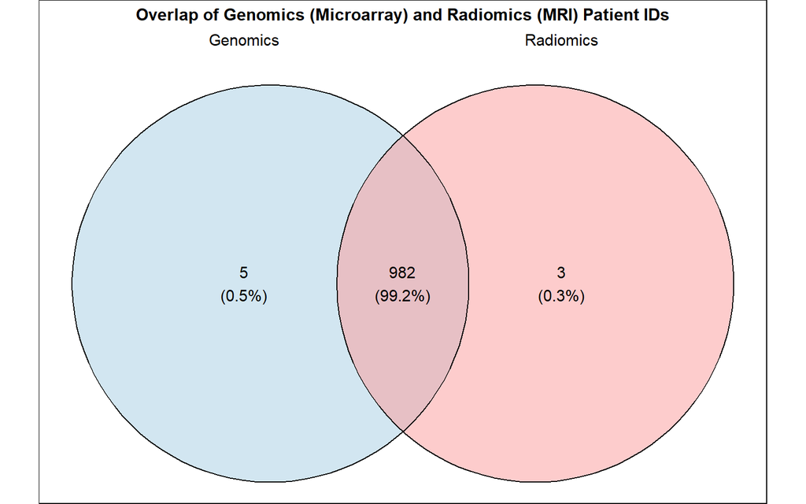

```r
# Create Venn diagram
venn_data <- list(Genomics = Genomics_clin$patientid, Radiomics = Radiomics_clin$Patient_ID)

ggvenn(venn_data, fill_color = c("#A6CEE3", "#FB9A99"), stroke_size = 0.5, set_name_size = 4) +
  ggtitle("Overlap of Genomics (Microarray) and Radiomics (MRI) Patient IDs") +
  theme(plot.title = element_text(hjust = 0.5, size = 12, face = "bold"), plot.background = element_rect(fill = "white"), panel.background = element_blank())
```

## Merge Genomics & Radiomics Data

Merging both datasets based on **common patient IDs**.

**Adjustments:**  
- **Prefix MRI columns with `"Radiomics_"`**  
- **Ensure consistent patient IDs**  
- **Save merged dataset for analysis**

```r
# Add prefix to radiomics columns
colnames(Radiomics_clin)[-which(colnames(Radiomics_clin) == "Patient_ID")] <- paste0("Radiomics_", colnames(Radiomics_clin)[-which(colnames(Radiomics_clin) == "Patient_ID")])

# Merge datasets
merged_clin <- merge(Genomics_clin, Radiomics_clin, by.x = "patientid", by.y = "Patient_ID")

# Sort by patient ID
merged_clin <- merged_clin[order(merged_clin$patientid), ]

# Display merged dataset with scrolling
kable(head(merged_clin,50), caption = "Merged Clinical Data (Genomics & Radiomics)") %>%
  kable_styling(bootstrap_options = c("striped", "hover", "condensed"), full_width = FALSE) %>%
  scroll_box(height = "400px")
```

Merged Clinical Data (Genomics & Radiomics)

| patientid | sex | age | cancer_type | histo | tissueid | stage | response.other.info | recist | response | treatment | dna | rna | survival_time_pfs | event_occurred_pfs | survival_time_os | event_occurred_os | survival_unit | survival_type | TMB_raw | nsTMB_raw | indel_TMB_raw | indel_nsTMB_raw | TMB_perMb | nsTMB_perMb | indel_TMB_perMb | indel_nsTMB_perMb | CIN | CNA_tot | AMP | … |
| --- | --- | --- | --- | --- | --- | --- | --- | --- | --- | --- | --- | --- | --- | --- | --- | --- | --- | --- | --- | --- | --- | --- | --- | --- | --- | --- | --- | --- | --- | --- |
| 100899 | F | NA | Breast | NA | Breast | NA | NR | NA | NR | chemo+targeted | NA | microarray | NA | NA | NA | NA | NA | None | NA | NA | NA | NA | NA | NA | NA | NA | NA | NA | NA | … |
| 102011 | F | NA | Breast | NA | Breast | NA | NR | NA | NR | chemo+targeted | NA | microarray | NA | NA | NA | NA | NA | None | NA | NA | NA | NA | NA | NA | NA | NA | NA | NA | NA | … |
| 102212 | F | NA | Breast | NA | Breast | NA | NR | NA | NR | chemo+targeted | NA | microarray | NA | NA | NA | NA | NA | None | NA | NA | NA | NA | NA | NA | NA | NA | NA | NA | NA | … |
| 103693 | F | NA | Breast | NA | Breast | NA | NR | NA | NR | IO+chemo | NA | microarray | NA | NA | NA | NA | NA | None | NA | NA | NA | NA | NA | NA | NA | NA | NA | NA | NA | … |
| 103939 | F | NA | Breast | NA | Breast | NA | NR | NA | NR | chemo | NA | microarray | NA | NA | NA | NA | NA | None | NA | NA | NA | NA | NA | NA | NA | NA | NA | NA | NA | … |
| 104268 | F | NA | Breast | NA | Breast | NA | NR | NA | NR | chemo | NA | microarray | NA | NA | NA | NA | NA | None | NA | NA | NA | NA | NA | NA | NA | NA | NA | NA | NA | … |
| 104384 | F | NA | Breast | NA | Breast | NA | NR | NA | NR | IO+chemo | NA | microarray | NA | NA | NA | NA | NA | None | NA | NA | NA | NA | NA | NA | NA | NA | NA | NA | NA | … |
| 105286 | F | NA | Breast | NA | Breast | NA | NR | NA | NR | chemo+targeted | NA | microarray | NA | NA | NA | NA | NA | None | NA | NA | NA | NA | NA | NA | NA | NA | NA | NA | NA | … |
| 105513 | F | NA | Breast | NA | Breast | NA | R | NA | R | chemo+targeted | NA | microarray | NA | NA | NA | NA | NA | None | NA | NA | NA | NA | NA | NA | NA | NA | NA | NA | NA | … |
| 107700 | F | NA | Breast | NA | Breast | NA | NR | NA | NR | chemo+targeted | NA | microarray | NA | NA | NA | NA | NA | None | NA | NA | NA | NA | NA | NA | NA | NA | NA | NA | NA | … |
| 108939 | F | NA | Breast | NA | Breast | NA | R | NA | R | chemo+targeted | NA | microarray | NA | NA | NA | NA | NA | None | NA | NA | NA | NA | NA | NA | NA | NA | NA | NA | NA | … |
| 108969 | F | NA | Breast | NA | Breast | NA | R | NA | R | chemo+targeted | NA | microarray | NA | NA | NA | NA | NA | None | NA | NA | NA | NA | NA | NA | NA | NA | NA | NA | NA | … |
| 109623 | F | NA | Breast | NA | Breast | NA | NR | NA | NR | chemo+targeted | NA | microarray | NA | NA | NA | NA | NA | None | NA | NA | NA | NA | NA | NA | NA | NA | NA | NA | NA | … |
| 109874 | F | NA | Breast | NA | Breast | NA | R | NA | R | chemo+targeted | NA | microarray | NA | NA | NA | NA | NA | None | NA | NA | NA | NA | NA | NA | NA | NA | NA | NA | NA | … |
| 109980 | F | NA | Breast | NA | Breast | NA | R | NA | R | chemo+targeted | NA | microarray | NA | NA | NA | NA | NA | None | NA | NA | NA | NA | NA | NA | NA | NA | NA | NA | NA | … |
| 111004 | F | NA | Breast | NA | Breast | NA | NR | NA | NR | IO+chemo | NA | microarray | NA | NA | NA | NA | NA | None | NA | NA | NA | NA | NA | NA | NA | NA | NA | NA | NA | … |
| 111038 | F | NA | Breast | NA | Breast | NA | NR | NA | NR | chemo+targeted | NA | microarray | NA | NA | NA | NA | NA | None | NA | NA | NA | NA | NA | NA | NA | NA | NA | NA | NA | … |
| 111344 | F | NA | Breast | NA | Breast | NA | NR | NA | NR | chemo+targeted | NA | microarray | NA | NA | NA | NA | NA | None | NA | NA | NA | NA | NA | NA | NA | NA | NA | NA | NA | … |
| 111646 | F | NA | Breast | NA | Breast | NA | NR | NA | NR | chemo+targeted | NA | microarray | NA | NA | NA | NA | NA | None | NA | NA | NA | NA | NA | NA | NA | NA | NA | NA | NA | … |
| 111674 | F | NA | Breast | NA | Breast | NA | R | NA | R | chemo+targeted | NA | microarray | NA | NA | NA | NA | NA | None | NA | NA | NA | NA | NA | NA | NA | NA | NA | NA | NA | … |
| 111881 | F | NA | Breast | NA | Breast | NA | R | NA | R | chemo+targeted | NA | microarray | NA | NA | NA | NA | NA | None | NA | NA | NA | NA | NA | NA | NA | NA | NA | NA | NA | … |
| 112606 | F | NA | Breast | NA | Breast | NA | NR | NA | NR | chemo+targeted | NA | microarray | NA | NA | NA | NA | NA | None | NA | NA | NA | NA | NA | NA | NA | NA | NA | NA | NA | … |
| 114087 | F | NA | Breast | NA | Breast | NA | NR | NA | NR | IO+chemo | NA | microarray | NA | NA | NA | NA | NA | None | NA | NA | NA | NA | NA | NA | NA | NA | NA | NA | NA | … |
| 115638 | F | NA | Breast | NA | Breast | NA | NR | NA | NR | chemo+targeted | NA | microarray | NA | NA | NA | NA | NA | None | NA | NA | NA | NA | NA | NA | NA | NA | NA | NA | NA | … |
| 115987 | F | NA | Breast | NA | Breast | NA | NR | NA | NR | chemo+targeted | NA | microarray | NA | NA | NA | NA | NA | None | NA | NA | NA | NA | NA | NA | NA | NA | NA | NA | NA | … |
| 116165 | F | NA | Breast | NA | Breast | NA | NR | NA | NR | IO+chemo | NA | microarray | NA | NA | NA | NA | NA | None | NA | NA | NA | NA | NA | NA | NA | NA | NA | NA | NA | … |
| 116603 | F | NA | Breast | NA | Breast | NA | NR | NA | NR | chemo | NA | microarray | NA | NA | NA | NA | NA | None | NA | NA | NA | NA | NA | NA | NA | NA | NA | NA | NA | … |
| 117424 | F | NA | Breast | NA | Breast | NA | R | NA | R | chemo+targeted | NA | microarray | NA | NA | NA | NA | NA | None | NA | NA | NA | NA | NA | NA | NA | NA | NA | NA | NA | … |
| 117707 | F | NA | Breast | NA | Breast | NA | R | NA | R | chemo+targeted | NA | microarray | NA | NA | NA | NA | NA | None | NA | NA | NA | NA | NA | NA | NA | NA | NA | NA | NA | … |
| 118307 | F | NA | Breast | NA | Breast | NA | NR | NA | NR | chemo+targeted | NA | microarray | NA | NA | NA | NA | NA | None | NA | NA | NA | NA | NA | NA | NA | NA | NA | NA | NA | … |
| 119928 | F | NA | Breast | NA | Breast | NA | NR | NA | NR | chemo+targeted | NA | microarray | NA | NA | NA | NA | NA | None | NA | NA | NA | NA | NA | NA | NA | NA | NA | NA | NA | … |
| 120001 | F | NA | Breast | NA | Breast | NA | NR | NA | NR | chemo+targeted | NA | microarray | NA | NA | NA | NA | NA | None | NA | NA | NA | NA | NA | NA | NA | NA | NA | NA | NA | … |
| 120422 | F | NA | Breast | NA | Breast | NA | R | NA | R | chemo+targeted | NA | microarray | NA | NA | NA | NA | NA | None | NA | NA | NA | NA | NA | NA | NA | NA | NA | NA | NA | … |
| 122287 | F | NA | Breast | NA | Breast | NA | R | NA | R | targeted | NA | microarray | NA | NA | NA | NA | NA | None | NA | NA | NA | NA | NA | NA | NA | NA | NA | NA | NA | … |
| 122579 | F | NA | Breast | NA | Breast | NA | NR | NA | NR | chemo | NA | microarray | NA | NA | NA | NA | NA | None | NA | NA | NA | NA | NA | NA | NA | NA | NA | NA | NA | … |
| 122795 | F | NA | Breast | NA | Breast | NA | NR | NA | NR | chemo+targeted | NA | microarray | NA | NA | NA | NA | NA | None | NA | NA | NA | NA | NA | NA | NA | NA | NA | NA | NA | … |
| 123660 | F | NA | Breast | NA | Breast | NA | NR | NA | NR | chemo+targeted | NA | microarray | NA | NA | NA | NA | NA | None | NA | NA | NA | NA | NA | NA | NA | NA | NA | NA | NA | … |
| 125130 | F | NA | Breast | NA | Breast | NA | R | NA | R | targeted | NA | microarray | NA | NA | NA | NA | NA | None | NA | NA | NA | NA | NA | NA | NA | NA | NA | NA | NA | … |
| 125418 | F | NA | Breast | NA | Breast | NA | NR | NA | NR | chemo+targeted | NA | microarray | NA | NA | NA | NA | NA | None | NA | NA | NA | NA | NA | NA | NA | NA | NA | NA | NA | … |
| 127675 | F | NA | Breast | NA | Breast | NA | NR | NA | NR | chemo+targeted | NA | microarray | NA | NA | NA | NA | NA | None | NA | NA | NA | NA | NA | NA | NA | NA | NA | NA | NA | … |
| 127791 | F | NA | Breast | NA | Breast | NA | NR | NA | NR | chemo+targeted | NA | microarray | NA | NA | NA | NA | NA | None | NA | NA | NA | NA | NA | NA | NA | NA | NA | NA | NA | … |
| 128051 | F | NA | Breast | NA | Breast | NA | NR | NA | NR | targeted | NA | microarray | NA | NA | NA | NA | NA | None | NA | NA | NA | NA | NA | NA | NA | NA | NA | NA | NA | … |
| 128675 | F | NA | Breast | NA | Breast | NA | R | NA | R | chemo | NA | microarray | NA | NA | NA | NA | NA | None | NA | NA | NA | NA | NA | NA | NA | NA | NA | NA | NA | … |
| 129837 | F | NA | Breast | NA | Breast | NA | NR | NA | NR | chemo+targeted | NA | microarray | NA | NA | NA | NA | NA | None | NA | NA | NA | NA | NA | NA | NA | NA | NA | NA | NA | … |
| 129973 | F | NA | Breast | NA | Breast | NA | R | NA | R | chemo+targeted | NA | microarray | NA | NA | NA | NA | NA | None | NA | NA | NA | NA | NA | NA | NA | NA | NA | NA | NA | … |
| 130580 | F | NA | Breast | NA | Breast | NA | R | NA | R | chemo+targeted | NA | microarray | NA | NA | NA | NA | NA | None | NA | NA | NA | NA | NA | NA | NA | NA | NA | NA | NA | … |
| 130892 | F | NA | Breast | NA | Breast | NA | R | NA | R | chemo+targeted | NA | microarray | NA | NA | NA | NA | NA | None | NA | NA | NA | NA | NA | NA | NA | NA | NA | NA | NA | … |
| 131595 | F | NA | Breast | NA | Breast | NA | NR | NA | NR | chemo+targeted | NA | microarray | NA | NA | NA | NA | NA | None | NA | NA | NA | NA | NA | NA | NA | NA | NA | NA | NA | … |
| 131961 | F | NA | Breast | NA | Breast | NA | R | NA | R | targeted | NA | microarray | NA | NA | NA | NA | NA | None | NA | NA | NA | NA | NA | NA | NA | NA | NA | NA | NA | … |
| 132463 | F | NA | Breast | NA | Breast | NA | R | NA | R | chemo+targeted | NA | microarray | NA | NA | NA | NA | NA | None | NA | NA | NA | NA | NA | NA | NA | NA | NA | NA | NA | … |

```r
# Save dataset as CSV
# write.csv(merged_clin, "~/BHK lab/I-SPY-Project/output Data/Merged_clin_GenomicandRadiomic.csv", row.names = FALSE)
```

### Verifying Segmentation Consistency Across Patients

To ensure accurate **Functional Tumor Volume (FTV)** analysis in the I-SPY clinical trials, we verify that each patient has the expected **4 segmentation masks** from **Dynamic Contrast Enhanced (DCE) MRI** scans.

### Segmentation Process in DCE-MRI

Each scan undergoes multiple segmentation steps:  
1. **Manual VOI (Volume of Interest):** A rectangular region around the enhancing tumor.  
2. **Background Masking:** Removes noise and fat saturation artifacts.  
3. **Percent Enhancement (PE) Threshold:** Filters non-enhancing tissue.  
4. **Connectivity Filter:** Ensures 3D tumor voxel connectivity.  
5. **OMIT Regions:** Manual exclusion of non-tumor areas.

note: **Segmentation masks are stored as 2D DICOM images** aligned with the original **DCE MRI scans**.  
note: **Download masks from UCSF Box:** [Link](https://ucsf.box.com/s/d09xetaatzgnz2p9bxlqh50rrzilgcoj)

### Segmentation Metadata

#### ISPY1: MRI Series Metadata

Metadata for ISPY1 is stored in `ispy1_dce_series_info.xlsx` with 221 patients. This dataset contains MRI series metadata for each patient, including:  
- **Patient ID & Time Point (T1-T4)**  
- **MRI Series Description & Unique ID**  
- **Signal Enhancement Ratio (SER) Calculation Indicator**  
- **OMIT Region Counts (Non-Tumor Exclusion)**

```r
# Load ISPY1 segmentation metadata
ispy1_dce_series_info <- read_excel(
  path = file.path(base_dir, "Source Data", "ispy1_dce_series_info.xlsx"),
  sheet = "DCE Series, All 20160823"
)

# Display ISPY1 segmentation metadata
kable(head(ispy1_dce_series_info, 20), caption = "DCE MRI Series Information") %>%
  kable_styling(bootstrap_options = c("striped", "hover", "condensed"), full_width = FALSE) %>%
  scroll_box(height = "400px")
```

DCE MRI Series Information

| PATIENT_ID | SUBJECT_NO | TIME_POINT | VISIT | SERIES_DESC | SERIES_ID | SERIES_TYPE | SERIES_CAT | STUDY_UID | SERIES_UID | SERIES_PATH | PRIMARY_AIM | GOOD_VOLSER | VOLSER | ACQ_POST_PHASES | PRE_PHASE_INDEX | EARLY_PHASE_INDEX | LATE_PHASE_INDEX | OMIT_ROI_COUNT | BACKGROUND_PCT | BACKGROUND_THRESHOLD | PE_THRESHOLD | MIN_NEIGHBOR_COUNT | EARLY_DELAY | LATE_DELAY | VOI_CENTER_RL | VOI_CENTER_AP | VOI_CENTER_SI | VOI_HALF_WIDTH_RL | VOI_HALF_WIDTH_AP | … |
| --- | --- | --- | --- | --- | --- | --- | --- | --- | --- | --- | --- | --- | --- | --- | --- | --- | --- | --- | --- | --- | --- | --- | --- | --- | --- | --- | --- | --- | --- | --- |
| ISPY1_1001 | 1001 | T1 | 10 | Dynamic-3dfgre | 4 | dce/post | dce pre post | 1.3.6.1.4.1.14519.5.2.1.7695.1700.162588073261248159118785473116 | 1.3.6.1.4.1.14519.5.2.1.7695.1700.334491271566855314830260417024 | ISPY1/ISPY1_1001/1.3.6.1.4.1.14519.5.2.1.7695.1700.162588073261248159118785473116/1.3.6.1.4.1.14519.5.2.1.7695.1700.334491271566855314830260417024 | 1 | 1 | yes | 2 | 0 | 1 | 2 | NA | 60 | 57 | 70 | 4 | 142.908 | 471.909 | 82.89999 | -44.875000 | -12.7500000 | 0 | 39.84375 | … |
| ISPY1_1001 | 1001 | T2 | 20 | Dynamic-3dfgre | 3 | dce/post | dce pre post | 1.3.6.1.4.1.14519.5.2.1.7695.1700.251725059071532256976802593346 | 1.3.6.1.4.1.14519.5.2.1.7695.1700.284567351304426376226790714264 | ISPY1/ISPY1_1001/1.3.6.1.4.1.14519.5.2.1.7695.1700.251725059071532256976802593346/1.3.6.1.4.1.14519.5.2.1.7695.1700.284567351304426376226790714264 | 1 | 1 | yes | 2 | 0 | 1 | 2 | NA | 60 | 50 | 70 | 9 | 142.908 | 504.909 | 102.00000 | -46.503125 | -45.1562500 | 0 | 44.92188 | … |
| ISPY1_1001 | 1001 | T3 | 30 | Dynamic-3dfgre | 4 | dce/post | dce pre post | 1.3.6.1.4.1.14519.5.2.1.7695.1700.186130315530827043916665138479 | 1.3.6.1.4.1.14519.5.2.1.7695.1700.229054711046553504545787083659 | ISPY1/ISPY1_1001/1.3.6.1.4.1.14519.5.2.1.7695.1700.186130315530827043916665138479/1.3.6.1.4.1.14519.5.2.1.7695.1700.229054711046553504545787083659 | 1 | 1 | yes | 2 | 0 | 1 | 2 | NA | 60 | NA | 70 | 4 | 142.908 | 467.909 | 75.80000 | -35.546875 | 14.2031250 | 0 | 43.35938 | … |
| ISPY1_1001 | 1001 | T4 | 40 | Dynamic-3dfgre | 4 | dce/post | dce pre post | 1.3.6.1.4.1.14519.5.2.1.7695.1700.118757564401397374205631727107 | 1.3.6.1.4.1.14519.5.2.1.7695.1700.195983148423034180376334647727 | ISPY1/ISPY1_1001/1.3.6.1.4.1.14519.5.2.1.7695.1700.118757564401397374205631727107/1.3.6.1.4.1.14519.5.2.1.7695.1700.195983148423034180376334647727 | 1 | 1 | yes | 2 | 0 | 1 | 2 | NA | 60 | NA | 70 | 9 | 142.908 | 469.909 | 68.70000 | -47.659374 | 9.1562500 | 0 | 37.10938 | … |
| ISPY1_1002 | 1002 | T1 | 10 | Dynamic-3dfgre | 3 | dce/post | dce pre post | 1.3.6.1.4.1.14519.5.2.1.7695.1700.134976640792500085117907460097 | 1.3.6.1.4.1.14519.5.2.1.7695.1700.200978610610642152304681086604 | ISPY1/ISPY1_1002/1.3.6.1.4.1.14519.5.2.1.7695.1700.134976640792500085117907460097/1.3.6.1.4.1.14519.5.2.1.7695.1700.200978610610642152304681086604 | 1 | 1 | yes | 2 | 0 | 1 | 2 | NA | 60 | 47 | 70 | 4 | 142.908 | 487.909 | -120.10000 | -8.543750 | 2.0156250 | 0 | 24.21875 | … |
| ISPY1_1002 | 1002 | T2 | 20 | Dynamic-3dfgre | 3 | dce/post | dce pre post | 1.3.6.1.4.1.14519.5.2.1.7695.1700.213299857546682356325308543300 | 1.3.6.1.4.1.14519.5.2.1.7695.1700.217629313261264666455404162928 | ISPY1/ISPY1_1002/1.3.6.1.4.1.14519.5.2.1.7695.1700.213299857546682356325308543300/1.3.6.1.4.1.14519.5.2.1.7695.1700.217629313261264666455404162928 | 1 | 1 | yes | 2 | 0 | 1 | 2 | NA | 60 | 49 | 70 | 4 | 142.908 | 455.909 | -108.60000 | -15.184375 | 17.8125000 | 0 | 18.35938 | … |
| ISPY1_1002 | 1002 | T3 | 30 | Dynamic-3dfgre | 5 | dce/post | dce pre post | 1.3.6.1.4.1.14519.5.2.1.7695.1700.310641334810324025592282005680 | 1.3.6.1.4.1.14519.5.2.1.7695.1700.308304415889255945632238319959 | ISPY1/ISPY1_1002/1.3.6.1.4.1.14519.5.2.1.7695.1700.310641334810324025592282005680/1.3.6.1.4.1.14519.5.2.1.7695.1700.308304415889255945632238319959 | 1 | 1 | yes | 2 | 0 | 1 | 2 | NA | 60 | NA | 70 | 4 | 142.908 | 480.909 | -124.50000 | -9.768749 | -0.5000000 | 0 | 12.50000 | … |
| ISPY1_1002 | 1002 | T4 | 40 | Dynamic-3dfgre | 4 | dce/post | dce pre post | 1.3.6.1.4.1.14519.5.2.1.7695.1700.161260768808765067428187568337 | 1.3.6.1.4.1.14519.5.2.1.7695.1700.123719184220486274456682769238 | ISPY1/ISPY1_1002/1.3.6.1.4.1.14519.5.2.1.7695.1700.161260768808765067428187568337/1.3.6.1.4.1.14519.5.2.1.7695.1700.123719184220486274456682769238 | 1 | 1 | yes | 2 | 0 | 1 | 2 | NA | 60 | NA | 70 | 4 | 142.908 | 464.909 | -107.00000 | -10.784375 | -13.3906250 | 0 | 18.35938 | … |
| ISPY1_1003 | 1003 | T1 | 10 | Dynamic-3dfgre | 3 | dce/post | dce pre post | 1.3.6.1.4.1.14519.5.2.1.7695.1700.298080081174310898419212435677 | 1.3.6.1.4.1.14519.5.2.1.7695.1700.217966338988546791542147267475 | ISPY1/ISPY1_1003/1.3.6.1.4.1.14519.5.2.1.7695.1700.298080081174310898419212435677/1.3.6.1.4.1.14519.5.2.1.7695.1700.217966338988546791542147267475 | 1 | 1 | yes | 2 | 0 | 1 | 2 | NA | 60 | 41 | 70 | 4 | 142.908 | 464.909 | 80.00000 | -42.150000 | -38.9531250 | 0 | 39.84375 | … |
| ISPY1_1003 | 1003 | T2 | 20 | Dynamic-3dfgre | 4 | dce/post | dce pre post | 1.3.6.1.4.1.14519.5.2.1.7695.1700.138213557573473307011258165864 | 1.3.6.1.4.1.14519.5.2.1.7695.1700.299956820661297346246226539430 | ISPY1/ISPY1_1003/1.3.6.1.4.1.14519.5.2.1.7695.1700.138213557573473307011258165864/1.3.6.1.4.1.14519.5.2.1.7695.1700.299956820661297346246226539430 | 1 | 1 | yes | 2 | 0 | 1 | 2 | 1 | 60 | 49 | 70 | 4 | 142.908 | 448.909 | 85.89999 | -20.403125 | 23.5281260 | 0 | 33.98438 | … |
| ISPY1_1003 | 1003 | T3 | 30 | Dynamic-3dfgre | 4 | dce/post | dce pre post | 1.3.6.1.4.1.14519.5.2.1.7695.1700.266827030532815128632203224043 | 1.3.6.1.4.1.14519.5.2.1.7695.1700.160218149129103458523671303946 | ISPY1/ISPY1_1003/1.3.6.1.4.1.14519.5.2.1.7695.1700.266827030532815128632203224043/1.3.6.1.4.1.14519.5.2.1.7695.1700.160218149129103458523671303946 | 1 | 1 | yes | 2 | 0 | 1 | 2 | NA | 60 | NA | 70 | 4 | 142.908 | 467.909 | 84.89999 | -31.143750 | -10.5156250 | 0 | 30.46875 | … |
| ISPY1_1003 | 1003 | T4 | 40 | Dynamic-3dfgre | 4 | dce/post | dce pre post | 1.3.6.1.4.1.14519.5.2.1.7695.1700.268904421322788588680650702521 | 1.3.6.1.4.1.14519.5.2.1.7695.1700.333833341467598933118786229456 | ISPY1/ISPY1_1003/1.3.6.1.4.1.14519.5.2.1.7695.1700.268904421322788588680650702521/1.3.6.1.4.1.14519.5.2.1.7695.1700.333833341467598933118786229456 | 1 | 1 | yes | 2 | 0 | 1 | 2 | NA | 60 | NA | 70 | 9 | 142.908 | 477.909 | 82.40000 | -33.162500 | -23.6875000 | 0 | 26.56250 | … |
| ISPY1_1004 | 1004 | T1 | 10 | CTLMID,Sag,3D,SPGR,VBw, GRx, | 2 | dce/post | dce pre post | 1.3.6.1.4.1.14519.5.2.1.7695.1700.123666578177897342122858721875 | 1.3.6.1.4.1.14519.5.2.1.7695.1700.228597508795509915957044689330 | ISPY1/ISPY1_1004/1.3.6.1.4.1.14519.5.2.1.7695.1700.123666578177897342122858721875/1.3.6.1.4.1.14519.5.2.1.7695.1700.228597508795509915957044689330 | 1 | 1 | yes | 2 | 0 | 1 | 2 | NA | 65 | 72 | 90 | 13 | 204.500 | 613.500 | 78.75000 | -43.484375 | 19.2500000 | 0 | 36.91406 | … |
| ISPY1_1004 | 1004 | T2 | 20 | PELVIC,Sag,3D,SPGR,VBw, GRx, | 2 | dce/post | dce pre post | 1.3.6.1.4.1.14519.5.2.1.7695.1700.139210337184334513376946376405 | 1.3.6.1.4.1.14519.5.2.1.7695.1700.300426672774245107955438830162 | ISPY1/ISPY1_1004/1.3.6.1.4.1.14519.5.2.1.7695.1700.139210337184334513376946376405/1.3.6.1.4.1.14519.5.2.1.7695.1700.300426672774245107955438830162 | 1 | 1 | yes | 2 | 0 | 1 | 2 | NA | 65 | 90 | 90 | 13 | 182.000 | 546.000 | 77.55000 | -36.514069 | 1.5781250 | 0 | 35.85938 | … |
| ISPY1_1004 | 1004 | T3 | 30 | CTLMID,Sag,3D,SPGR,VBw, GRx, | 3 | dce/post | dce pre post | 1.3.6.1.4.1.14519.5.2.1.7695.1700.472960478717934840128915797201 | 1.3.6.1.4.1.14519.5.2.1.7695.1700.304375489738621951636388985164 | ISPY1/ISPY1_1004/1.3.6.1.4.1.14519.5.2.1.7695.1700.472960478717934840128915797201/1.3.6.1.4.1.14519.5.2.1.7695.1700.304375489738621951636388985164 | 1 | 1 | yes | 2 | 0 | 1 | 2 | NA | 65 | NA | 90 | 13 | 186.500 | 559.500 | 70.89999 | -39.962502 | 3.0312500 | 0 | 45.35156 | … |
| ISPY1_1004 | 1004 | T4 | 40 | CTLMID,Sag,3D,SPGR,VBw, GRx, | 3 | dce/post | dce pre post | 1.3.6.1.4.1.14519.5.2.1.7695.1700.293613141232081657976654600946 | 1.3.6.1.4.1.14519.5.2.1.7695.1700.794231212227579946078491333086 | ISPY1/ISPY1_1004/1.3.6.1.4.1.14519.5.2.1.7695.1700.293613141232081657976654600946/1.3.6.1.4.1.14519.5.2.1.7695.1700.794231212227579946078491333086 | 1 | 1 | yes | 2 | 0 | 1 | 2 | NA | 65 | NA | 90 | 13 | 200.000 | 600.000 | 76.90000 | -27.107811 | 5.4453125 | 0 | 18.98438 | … |
| ISPY1_1005 | 1005 | T1 | 10 | CTLMID,Sag,3D,SPGR,VBw, GRx, | 2 | dce/post | dce pre post | 1.3.6.1.4.1.14519.5.2.1.7695.1700.168682333761219918185990956754 | 1.3.6.1.4.1.14519.5.2.1.7695.1700.112512091674522544167508033512 | ISPY1/ISPY1_1005/1.3.6.1.4.1.14519.5.2.1.7695.1700.168682333761219918185990956754/1.3.6.1.4.1.14519.5.2.1.7695.1700.112512091674522544167508033512 | 1 | 1 | yes | 2 | 0 | 1 | 2 | NA | 65 | 73 | 90 | 13 | 175.500 | 526.500 | 79.90001 | -41.065628 | 39.2656250 | 0 | 46.05469 | … |
| ISPY1_1005 | 1005 | T2 | 20 | CTLMID,Sag,3D,SPGR,VBw, GRx, | 2 | dce/post | dce pre post | 1.3.6.1.4.1.14519.5.2.1.7695.1700.175394084652801531467726863292 | 1.3.6.1.4.1.14519.5.2.1.7695.1700.229410656917615455958078148940 | ISPY1/ISPY1_1005/1.3.6.1.4.1.14519.5.2.1.7695.1700.175394084652801531467726863292/1.3.6.1.4.1.14519.5.2.1.7695.1700.229410656917615455958078148940 | 0 | 0 | no | 1 | NA | NA | NA | NA | NA | NA | NA | NA | NA | NA | NA | NA | NA | NA | NA | … |
| ISPY1_1005 | 1005 | T3 | 30 | CTLMID,Sag,3D,SPGR,VBw, GRx, | 4 | dce/post | dce pre post | 1.3.6.1.4.1.14519.5.2.1.7695.1700.278680050483471060479946922896 | 1.3.6.1.4.1.14519.5.2.1.7695.1700.253971398051889701206388702985 | ISPY1/ISPY1_1005/1.3.6.1.4.1.14519.5.2.1.7695.1700.278680050483471060479946922896/1.3.6.1.4.1.14519.5.2.1.7695.1700.253971398051889701206388702985 | 0 | 1 | yes | 2 | 0 | 1 | 2 | NA | 65 | 70 | 90 | 13 | 206.500 | 619.500 | 72.40313 | -48.245316 | -0.1796875 | 0 | 46.05469 | … |
| ISPY1_1005 | 1005 | T4 | 40 | 3D | 5 | dce/post | dce pre post | 1.3.6.1.4.1.14519.5.2.1.7695.1700.315178405770722394134357255715 | 1.3.6.1.4.1.14519.5.2.1.7695.1700.244038849484388506230960714412 | ISPY1/ISPY1_1005/1.3.6.1.4.1.14519.5.2.1.7695.1700.315178405770722394134357255715/1.3.6.1.4.1.14519.5.2.1.7695.1700.244038849484388506230960714412 | 1 | 1 | yes | 2 | 0 | 1 | 2 | NA | 65 | NA | 90 | 13 | 146.369 | 621.369 | 86.80000 | -37.195313 | 31.5546880 | 0 | 39.02344 | … |

#### ISPY2: MRI Series Metadata

Metadata for ISPY2 was extracted from `series-data1741883133411.csv` with 719 patients.  
- **Subject.ID** - **Study.Description** exmaple “ISPY2_MRI_T0” “ISPY2_MRI_T0” “ISPY2_MRI_T0” “ISPY2_MRI_T0” “ISPY2_MRI_T0” “ISPY2_MRI_T0” -**“Number.of.images**: “MR” “SEG”

```r
# Load ISPY2 segmentation metadata
ispy2_dce_series_info <- read.csv(file.path(base_dir, "Source Data", "series-data1741883133411.csv"))

# Rename the "ispy2_dce_series_info" column to "PATIENT_ID"
colnames(ispy2_dce_series_info)[colnames(ispy2_dce_series_info) == "Subject.ID" ] <- "PATIENT_ID"

# Extract time points from the "Study.Description" column
ispy2_dce_series_info$TIME_POINT <- gsub(".*(T[0-9]+).*", "\\1", ispy2_dce_series_info$Study.Description)

# Display ISPY2 segmentation metadata
kable(head(ispy2_dce_series_info, 20), caption = "ISPY2 DCE MRI Series Information") %>%
  kable_styling(bootstrap_options = c("striped", "hover", "condensed"), full_width = FALSE) %>%
  scroll_box(height = "400px")
```

ISPY2 DCE MRI Series Information

| PATIENT_ID | Study.UID | Study.Description | Study.Date | Series.ID | Series.Description | Number.of.images | File.Size..Bytes. | Collection.Name | Modality | Manufacturer | X3rd.Party.Analysis | Data.Description.URI | Series.Number | License.Name | License.URL | Date.Released | Series.Date | Protocol.Name | Body.Part.Examined | Annotations.Flag | Manufacturer.Model.Name | Software.Versions | TimeStamp | TIME_POINT |
| --- | --- | --- | --- | --- | --- | --- | --- | --- | --- | --- | --- | --- | --- | --- | --- | --- | --- | --- | --- | --- | --- | --- | --- | --- |
| ISPY2-100899 | 1.3.6.1.4.1.14519.5.2.1.191407311082200176460176232508943888595 | ISPY2_MRI_T0 | 2002-10-26 | 1.3.6.1.4.1.14519.5.2.1.313330782407390298344661311370946136238 | ISPY2: SCOUT ISPY2 | 51 | 6827686 | ISPY2 | MR | GE MEDICAL SYSTEMS | NO | https://doi.org/10.7937/TCIA.D8Z0-9T85 | 1 | Creative Commons Attribution 4.0 International License | https://creativecommons.org/licenses/by/4.0/ | 2022-05-02 | 2002-10-26 | NA |  | NA | Signa HDxt | 24 | 2022-05-02 00:00:00.0 | T0 |
| ISPY2-100899 | 1.3.6.1.4.1.14519.5.2.1.191407311082200176460176232508943888595 | ISPY2_MRI_T0 | 2002-10-26 | 1.3.6.1.4.1.14519.5.2.1.279614487823636499235940907104792611414 | ISPY2: WATER:IDEAL | 45 | 23737674 | ISPY2 | MR | GE MEDICAL SYSTEMS | NO | https://doi.org/10.7937/TCIA.D8Z0-9T85 | 3 | Creative Commons Attribution 4.0 International License | https://creativecommons.org/licenses/by/4.0/ | 2022-05-02 | 2002-10-26 | NA |  | NA | Signa HDxt | 24 | 2022-05-02 00:00:00.0 | T0 |
| ISPY2-100899 | 1.3.6.1.4.1.14519.5.2.1.191407311082200176460176232508943888595 | ISPY2_MRI_T0 | 2002-10-26 | 1.3.6.1.4.1.14519.5.2.1.2647355698869417812524932280893489028 | ISPY2: FAT:IDEAL | 45 | 23737582 | ISPY2 | MR | GE MEDICAL SYSTEMS | NO | https://doi.org/10.7937/TCIA.D8Z0-9T85 | 300 | Creative Commons Attribution 4.0 International License | https://creativecommons.org/licenses/by/4.0/ | 2022-05-02 | 2002-10-26 | NA |  | NA | Signa HDxt | 24 | 2022-05-02 00:00:00.0 | T0 |
| ISPY2-100899 | 1.3.6.1.4.1.14519.5.2.1.191407311082200176460176232508943888595 | ISPY2_MRI_T0 | 2002-10-26 | 1.3.6.1.4.1.14519.5.2.1.206199927301215764245278347773827952523 | ISPY2: AX VIBRANT-SERIES | 106 | 55919746 | ISPY2 | MR | GE MEDICAL SYSTEMS | NO | https://doi.org/10.7937/TCIA.D8Z0-9T85 | 500 | Creative Commons Attribution 4.0 International License | https://creativecommons.org/licenses/by/4.0/ | 2022-05-02 | 2002-10-26 | NA |  | NA | Signa HDxt | 24 | 2022-05-02 00:00:00.0 | T0 |
| ISPY2-100899 | 1.3.6.1.4.1.14519.5.2.1.191407311082200176460176232508943888595 | ISPY2_MRI_T0 | 2002-10-26 | 1.3.6.1.4.1.14519.5.2.1.266124567498488197926988477469957203969 | ISPY2: Ph1/AX VIBRANT-SERIES | 106 | 55924242 | ISPY2 | MR | GE MEDICAL SYSTEMS | NO | https://doi.org/10.7937/TCIA.D8Z0-9T85 | 501 | Creative Commons Attribution 4.0 International License | https://creativecommons.org/licenses/by/4.0/ | 2022-05-02 | 2002-10-26 | NA |  | NA | Signa HDxt | 24 | 2022-05-02 00:00:00.0 | T0 |
| ISPY2-100899 | 1.3.6.1.4.1.14519.5.2.1.191407311082200176460176232508943888595 | ISPY2_MRI_T0 | 2002-10-26 | 1.3.6.1.4.1.14519.5.2.1.16099171300378572953268398707957231139 | ISPY2: Ph2/AX VIBRANT-SERIES | 106 | 55925922 | ISPY2 | MR | GE MEDICAL SYSTEMS | NO | https://doi.org/10.7937/TCIA.D8Z0-9T85 | 502 | Creative Commons Attribution 4.0 International License | https://creativecommons.org/licenses/by/4.0/ | 2022-05-02 | 2002-10-26 | NA |  | NA | Signa HDxt | 24 | 2022-05-02 00:00:00.0 | T0 |
| ISPY2-100899 | 1.3.6.1.4.1.14519.5.2.1.191407311082200176460176232508943888595 | ISPY2_MRI_T0 | 2002-10-26 | 1.3.6.1.4.1.14519.5.2.1.121895725493536428267661368492699481578 | ISPY2: Ph3/AX VIBRANT-SERIES | 106 | 55926114 | ISPY2 | MR | GE MEDICAL SYSTEMS | NO | https://doi.org/10.7937/TCIA.D8Z0-9T85 | 503 | Creative Commons Attribution 4.0 International License | https://creativecommons.org/licenses/by/4.0/ | 2022-05-02 | 2002-10-26 | NA |  | NA | Signa HDxt | 24 | 2022-05-02 00:00:00.0 | T0 |
| ISPY2-100899 | 1.3.6.1.4.1.14519.5.2.1.191407311082200176460176232508943888595 | ISPY2_MRI_T0 | 2002-10-26 | 1.3.6.1.4.1.14519.5.2.1.308685298008010400893831782399676642910 | ISPY2: Ph4/AX VIBRANT-SERIES | 106 | 55926134 | ISPY2 | MR | GE MEDICAL SYSTEMS | NO | https://doi.org/10.7937/TCIA.D8Z0-9T85 | 504 | Creative Commons Attribution 4.0 International License | https://creativecommons.org/licenses/by/4.0/ | 2022-05-02 | 2002-10-26 | NA |  | NA | Signa HDxt | 24 | 2022-05-02 00:00:00.0 | T0 |
| ISPY2-100899 | 1.3.6.1.4.1.14519.5.2.1.191407311082200176460176232508943888595 | ISPY2_MRI_T0 | 2002-10-26 | 1.3.6.1.4.1.14519.5.2.1.279756085626113072659714263260085690790 | ISPY2: Ph5/AX VIBRANT-SERIES | 106 | 55926134 | ISPY2 | MR | GE MEDICAL SYSTEMS | NO | https://doi.org/10.7937/TCIA.D8Z0-9T85 | 505 | Creative Commons Attribution 4.0 International License | https://creativecommons.org/licenses/by/4.0/ | 2022-05-02 | 2002-10-26 | NA |  | NA | Signa HDxt | 24 | 2022-05-02 00:00:00.0 | T0 |
| ISPY2-100899 | 1.3.6.1.4.1.14519.5.2.1.191407311082200176460176232508943888595 | ISPY2_MRI_T0 | 2002-10-26 | 1.3.6.1.4.1.14519.5.2.1.26092330643949841378637650049345388223 | ISPY2: Ph6/AX VIBRANT-SERIES | 106 | 55925942 | ISPY2 | MR | GE MEDICAL SYSTEMS | NO | https://doi.org/10.7937/TCIA.D8Z0-9T85 | 506 | Creative Commons Attribution 4.0 International License | https://creativecommons.org/licenses/by/4.0/ | 2022-05-02 | 2002-10-26 | NA |  | NA | Signa HDxt | 24 | 2022-05-02 00:00:00.0 | T0 |
| ISPY2-100899 | 1.3.6.1.4.1.14519.5.2.1.191407311082200176460176232508943888595 | ISPY2_MRI_T0 | 2002-10-26 | 1.3.6.1.4.1.14519.5.2.1.269426242885278506123547184297304481837 | ISPY2: Ph7/AX VIBRANT-SERIES | 106 | 55926102 | ISPY2 | MR | GE MEDICAL SYSTEMS | NO | https://doi.org/10.7937/TCIA.D8Z0-9T85 | 507 | Creative Commons Attribution 4.0 International License | https://creativecommons.org/licenses/by/4.0/ | 2022-05-02 | 2002-10-26 | NA |  | NA | Signa HDxt | 24 | 2022-05-02 00:00:00.0 | T0 |
| ISPY2-100899 | 1.3.6.1.4.1.14519.5.2.1.191407311082200176460176232508943888595 | ISPY2_MRI_T0 | 2002-10-26 | 1.3.6.1.4.1.14519.5.2.1.293975225635615618905200212057567133995 | ISPY2: VOLSER: uni-lateral cropped: SER | 80 | 10996402 | ISPY2 | MR | GE MEDICAL SYSTEMS | NO | https://doi.org/10.7937/TCIA.D8Z0-9T85 | 51000 | Creative Commons Attribution 4.0 International License | https://creativecommons.org/licenses/by/4.0/ | 2022-05-02 | 2002-10-26 | NA |  | NA | Signa HDxt |  | 2022-05-02 00:00:00.0 | T0 |
| ISPY2-100899 | 1.3.6.1.4.1.14519.5.2.1.191407311082200176460176232508943888595 | ISPY2_MRI_T0 | 2002-10-26 | 1.3.6.1.4.1.14519.5.2.1.192674667601251977965157561923468814958 | ISPY2: VOLSER: uni-lateral cropped: PE2 | 80 | 10919044 | ISPY2 | MR | GE MEDICAL SYSTEMS | NO | https://doi.org/10.7937/TCIA.D8Z0-9T85 | 51002 | Creative Commons Attribution 4.0 International License | https://creativecommons.org/licenses/by/4.0/ | 2022-05-02 | 2002-10-26 | NA |  | NA | Signa HDxt |  | 2022-05-02 00:00:00.0 | T0 |
| ISPY2-100899 | 1.3.6.1.4.1.14519.5.2.1.191407311082200176460176232508943888595 | ISPY2_MRI_T0 | 2002-10-26 | 1.3.6.1.4.1.14519.5.2.1.12678479245503031715538181201834554397 | ISPY2: VOLSER: uni-lateral cropped: PE5 | 80 | 10918864 | ISPY2 | MR | GE MEDICAL SYSTEMS | NO | https://doi.org/10.7937/TCIA.D8Z0-9T85 | 51005 | Creative Commons Attribution 4.0 International License | https://creativecommons.org/licenses/by/4.0/ | 2022-05-02 | 2002-10-26 | NA |  | NA | Signa HDxt |  | 2022-05-02 00:00:00.0 | T0 |
| ISPY2-100899 | 1.3.6.1.4.1.14519.5.2.1.191407311082200176460176232508943888595 | ISPY2_MRI_T0 | 2002-10-26 | 1.3.6.1.4.1.14519.5.2.1.89750556793240490681454008016631530523 | ISPY2: VOLSER: uni-lateral cropped: original DCE | 640 | 86184586 | ISPY2 | MR | GE MEDICAL SYSTEMS | NO | https://doi.org/10.7937/TCIA.D8Z0-9T85 | 51800 | Creative Commons Attribution 4.0 International License | https://creativecommons.org/licenses/by/4.0/ | 2022-05-02 | 2002-10-26 | NA |  | NA | Signa HDxt |  | 2022-05-02 00:00:00.0 | T0 |
| ISPY2-100899 | 1.3.6.1.4.1.14519.5.2.1.191407311082200176460176232508943888595 | ISPY2_MRI_T0 | 2002-10-26 | 1.3.6.1.4.1.14519.5.2.1.170670992519727173038447879955287778091 | ISPY2: VOLSER: uni-lateral cropped: Analysis Mask | 1 | 5285900 | ISPY2 | SEG | GE MEDICAL SYSTEMS | NO | https://doi.org/10.7937/TCIA.D8Z0-9T85 | 51900 | Creative Commons Attribution 4.0 International License | https://creativecommons.org/licenses/by/4.0/ | 2022-05-02 |  | NA | BREAST | NA | Signa HDxt | 220 | 2022-05-02 00:00:00.0 | T0 |
| ISPY2-100899 | 1.3.6.1.4.1.14519.5.2.1.313717101780375925531007251690743209330 | ISPY2_MRI_T1 | 2002-11-29 | 1.3.6.1.4.1.14519.5.2.1.92528379925157023915586133268003573401 | ISPY2: SCOUT ISPY2 | 51 | 6827804 | ISPY2 | MR | GE MEDICAL SYSTEMS | NO | https://doi.org/10.7937/TCIA.D8Z0-9T85 | 1 | Creative Commons Attribution 4.0 International License | https://creativecommons.org/licenses/by/4.0/ | 2022-05-02 | 2002-11-29 | NA |  | NA | Signa HDxt | 24 | 2022-05-02 00:00:00.0 | T1 |
| ISPY2-100899 | 1.3.6.1.4.1.14519.5.2.1.313717101780375925531007251690743209330 | ISPY2_MRI_T1 | 2002-11-29 | 1.3.6.1.4.1.14519.5.2.1.238689391857387503989892745238508896359 | ISPY2: WATER:IDEAL | 45 | 23737864 | ISPY2 | MR | GE MEDICAL SYSTEMS | NO | https://doi.org/10.7937/TCIA.D8Z0-9T85 | 3 | Creative Commons Attribution 4.0 International License | https://creativecommons.org/licenses/by/4.0/ | 2022-05-02 | 2002-11-29 | NA |  | NA | Signa HDxt | 24 | 2022-05-02 00:00:00.0 | T1 |
| ISPY2-100899 | 1.3.6.1.4.1.14519.5.2.1.313717101780375925531007251690743209330 | ISPY2_MRI_T1 | 2002-11-29 | 1.3.6.1.4.1.14519.5.2.1.91162948756112161226686952449027586143 | ISPY2: FAT:IDEAL | 45 | 23737796 | ISPY2 | MR | GE MEDICAL SYSTEMS | NO | https://doi.org/10.7937/TCIA.D8Z0-9T85 | 300 | Creative Commons Attribution 4.0 International License | https://creativecommons.org/licenses/by/4.0/ | 2022-05-02 | 2002-11-29 | NA |  | NA | Signa HDxt | 24 | 2022-05-02 00:00:00.0 | T1 |
| ISPY2-100899 | 1.3.6.1.4.1.14519.5.2.1.313717101780375925531007251690743209330 | ISPY2_MRI_T1 | 2002-11-29 | 1.3.6.1.4.1.14519.5.2.1.145698408400144867676386090516002449032 | ISPY2: AX VIBRANT-SERIES | 100 | 52767818 | ISPY2 | MR | GE MEDICAL SYSTEMS | NO | https://doi.org/10.7937/TCIA.D8Z0-9T85 | 600 | Creative Commons Attribution 4.0 International License | https://creativecommons.org/licenses/by/4.0/ | 2022-05-02 | 2002-11-29 | NA |  | NA | Signa HDxt | 24 | 2022-05-02 00:00:00.0 | T1 |

```r
# Select only PATIENT_ID and TIME_POINT columns from both datasets
ispy1_selected <- ispy1_dce_series_info[, c("PATIENT_ID", "TIME_POINT")]
ispy2_selected <- ispy2_dce_series_info[, c("PATIENT_ID", "TIME_POINT")]

# Merge based on PATIENT_ID and TIME_POINT
ispy1and2 <- merge(ispy1_selected, ispy2_selected, by = c("PATIENT_ID", "TIME_POINT"), all = TRUE)
```

### Check Segmentation Consistency Across Time Points (T1-T4)

Each patient (Total: 940) should have at least four segmentation masks, corresponding to their four MRI scans.

```r
# Count segmentations per patient for each time point
series_per_patient <- ispy1and2 %>%
  group_by(PATIENT_ID, TIME_POINT) %>%
  summarize(Series_Count = n(), .groups = 'drop') %>%
  pivot_wider(names_from = TIME_POINT, values_from = Series_Count, values_fill = 0) %>%
  mutate(across(starts_with("T"), as.numeric),
         Total_Segmentations = rowSums(select(., starts_with("T")), na.rm = TRUE))

# Display segmentation counts per patient
kable(series_per_patient, caption = "Segmentation Counts per Patient") %>%
  kable_styling(bootstrap_options = c("striped", "hover", "condensed"), full_width = FALSE) %>%
  scroll_box(height = "400px")
```

Segmentation Counts per Patient

| PATIENT_ID | T1 | T2 | T3 | T4 | T0 | Total_Segmentations |
| --- | --- | --- | --- | --- | --- | --- |
| ISPY1_1001 | 1 | 1 | 1 | 1 | 0 | 4 |
| ISPY1_1002 | 1 | 1 | 1 | 1 | 0 | 4 |
| ISPY1_1003 | 1 | 1 | 1 | 1 | 0 | 4 |
| ISPY1_1004 | 1 | 1 | 1 | 1 | 0 | 4 |
| ISPY1_1005 | 1 | 1 | 1 | 1 | 0 | 4 |
| ISPY1_1007 | 3 | 6 | 0 | 3 | 0 | 12 |
| ISPY1_1008 | 1 | 1 | 1 | 1 | 0 | 4 |
| ISPY1_1009 | 1 | 1 | 1 | 1 | 0 | 4 |
| ISPY1_1010 | 1 | 1 | 1 | 1 | 0 | 4 |
| ISPY1_1011 | 1 | 1 | 1 | 1 | 0 | 4 |
| ISPY1_1012 | 1 | 1 | 1 | 1 | 0 | 4 |
| ISPY1_1013 | 1 | 1 | 1 | 1 | 0 | 4 |
| ISPY1_1015 | 1 | 1 | 1 | 1 | 0 | 4 |
| ISPY1_1016 | 1 | 1 | 1 | 1 | 0 | 4 |
| ISPY1_1017 | 1 | 0 | 1 | 1 | 0 | 3 |
| ISPY1_1019 | 1 | 1 | 1 | 1 | 0 | 4 |
| ISPY1_1021 | 1 | 1 | 1 | 1 | 0 | 4 |
| ISPY1_1022 | 1 | 1 | 0 | 1 | 0 | 3 |
| ISPY1_1024 | 0 | 0 | 0 | 3 | 0 | 3 |
| ISPY1_1025 | 1 | 1 | 1 | 1 | 0 | 4 |
| ISPY1_1026 | 1 | 1 | 1 | 1 | 0 | 4 |
| ISPY1_1027 | 1 | 0 | 0 | 0 | 0 | 1 |
| ISPY1_1028 | 0 | 0 | 3 | 0 | 0 | 3 |
| ISPY1_1029 | 1 | 1 | 1 | 1 | 0 | 4 |
| ISPY1_1030 | 1 | 1 | 1 | 1 | 0 | 4 |
| ISPY1_1031 | 1 | 1 | 1 | 1 | 0 | 4 |
| ISPY1_1032 | 1 | 1 | 1 | 1 | 0 | 4 |
| ISPY1_1033 | 0 | 0 | 0 | 3 | 0 | 3 |
| ISPY1_1034 | 1 | 1 | 1 | 1 | 0 | 4 |
| ISPY1_1035 | 4 | 4 | 3 | 0 | 0 | 11 |

[output cut: 910 more lines]

### Patients with Missing Segmentations

Patients missing **one or more segmentation masks** need further review (24 patients).

```r
# Identify patients with <4 segmentations
patients_less_than_4 <- series_per_patient %>%
  filter(Total_Segmentations < 4) %>%
  select(PATIENT_ID, Total_Segmentations)

# Display patients missing segmentations
kable(patients_less_than_4, caption = "Patients with Less Than 4 Segmentation Masks") %>%
  kable_styling(bootstrap_options = c("striped", "hover", "condensed"), full_width = FALSE) %>%
  scroll_box(height = "400px")
```

Patients with Less Than 4 Segmentation Masks

| PATIENT_ID | Total_Segmentations |
| --- | --- |
| ISPY1_1017 | 3 |
| ISPY1_1022 | 3 |
| ISPY1_1024 | 3 |
| ISPY1_1027 | 1 |
| ISPY1_1028 | 3 |
| ISPY1_1033 | 3 |
| ISPY1_1036 | 3 |
| ISPY1_1040 | 3 |
| ISPY1_1044 | 1 |
| ISPY1_1048 | 3 |
| ISPY1_1050 | 1 |
| ISPY1_1051 | 3 |
| ISPY1_1087 | 3 |
| ISPY1_1094 | 3 |
| ISPY1_1095 | 3 |
| ISPY1_1101 | 3 |
| ISPY1_1120 | 3 |
| ISPY1_1138 | 3 |
| ISPY1_1140 | 3 |
| ISPY1_1145 | 3 |
| ISPY1_1176 | 2 |
| ISPY1_1215 | 1 |
| ISPY1_1227 | 3 |
| ISPY1_1231 | 3 |